# Données spatiales sur réseau

Marie-Pierre Etienne

marie-pierre.etienne@ensai.fr

ENSAI - CREST

https://marieetienne.github.io/statspat

2026-11-23

# Introduction

## Sources

Ce cours est construit à partir du livre de Cressie (2015) et de l’article Ver Hoef et al. (2018)

## Exemple illustratif

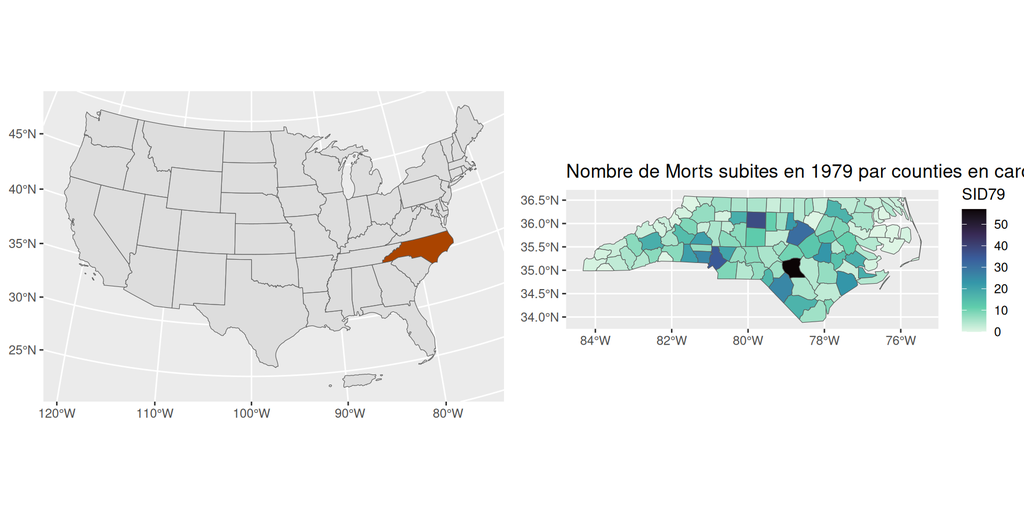

Les données sont ici des comptages par counties, mais on peut imaginer des prix au m2 par IRIS, des taux de chomage par IRIS etc ….

On cherche typiquement à ajuster un modèle de régression pour trouver des covariables liées au phénomène d’intérêt.

## Pourquoi faire attention à la corrélation spatiale

### Un exemple

$$Y_t = \rho Y_{t-1} +\varepsilon_t$$

```
            Estimate Std. Error  t value     Pr(>|t|)
(Intercept) 1.871456  0.3667672 5.102571 1.619417e-06
```

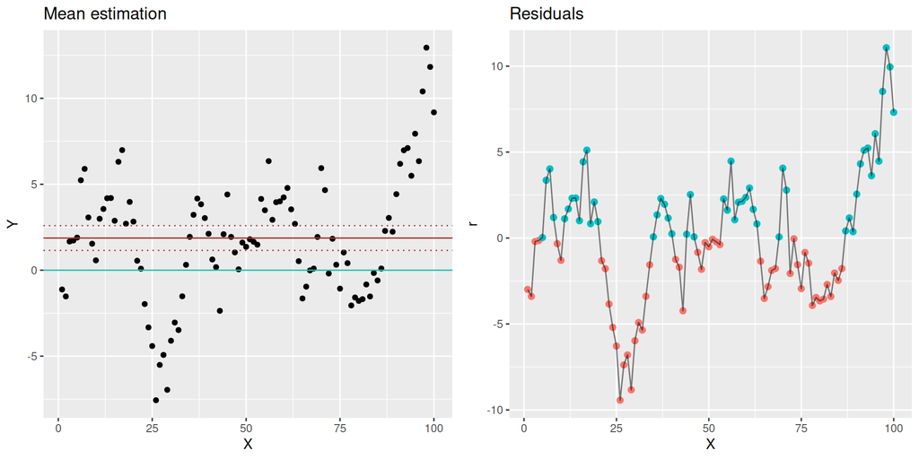

### Conséquence sur l’estimation

Variance de $\hat{\mu}$ :

- Cas indépendant $Var(\hat{\mu})= n^{-1} \sigma^2$
- Cas corrélé $Var(\hat{\mu})= n^{-1} \sigma^2 \left(1 + 2\left( \frac{\rho}{1-\rho}\right)\left( 1 -\frac{1}{n}\right) - 2 \left( \frac{\rho}{1-\rho}\right)^2 \left( \frac{1-\rho^{n-1}}{n}\right) \right)$

Ici on sous estime l’incertitude

## Quelques remarques

- Processus spatial est défini sur une grille : pas de réalisation possible entre deux localisation.
- on note $D$ l’ensemble des points de la grille
- On souhaite construire un modèle pour décrire la distribution du processus $Z$ en tout point $s$ de $D$

# Les modèles spatiaux sur grille et leur estimation

## Champs de Markov sur un réseau

Rappel: Si $(X_0,\ldots ,X_n, \ldots)$ est une chaîne de Markov, alors
$$\mathcal{L} \left ( X_{n+1} \vert X_{0:n}\right) = \mathcal{L} \left ( X_{n+1} \vert X_{n}\right)$$

Question : Etendre la propriété de Markov lorsque l’on n’a pas le sents du temps.

On va avoir besoin de la notion de voisins spatialement, que l’on peut représenter sous forme de graphe.

## Structure de graphes sur une grille régulière

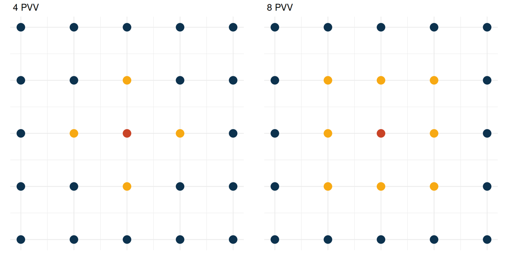

Représentation sous forme de graphe

# Que faire dans le cas des counties – grille non régulière

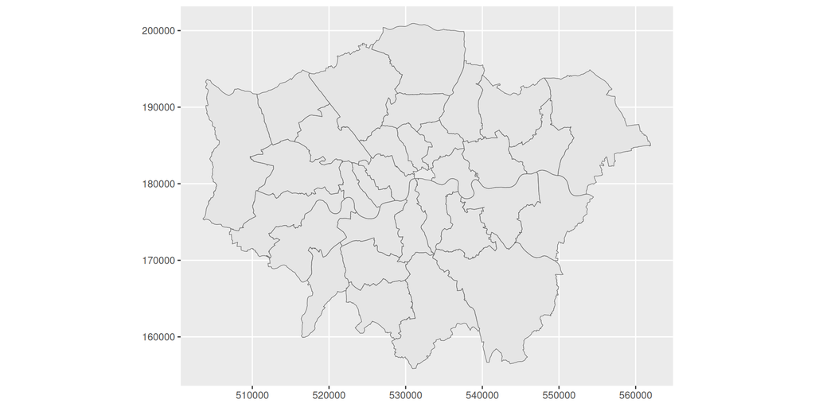

## Que faire dans le cas des counties – grille non régulière

On est voisin si on se touche

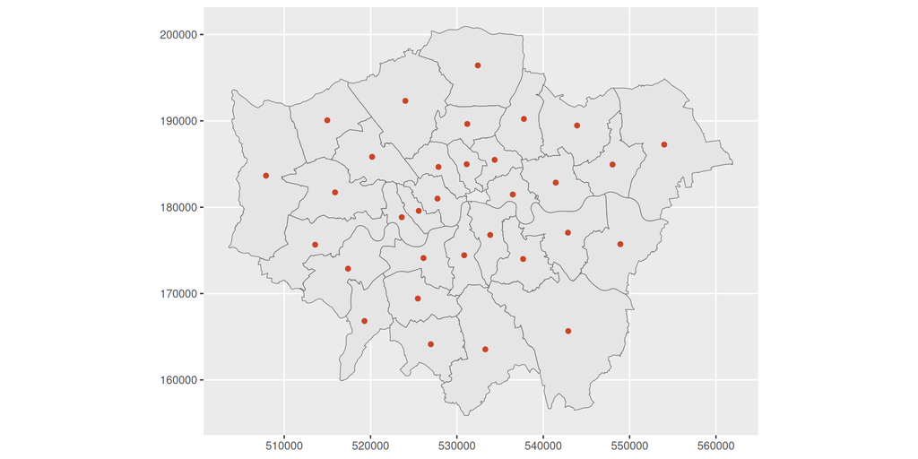

## Que faire dans le cas des counties – grille non régulière

On est voisin si on se touche

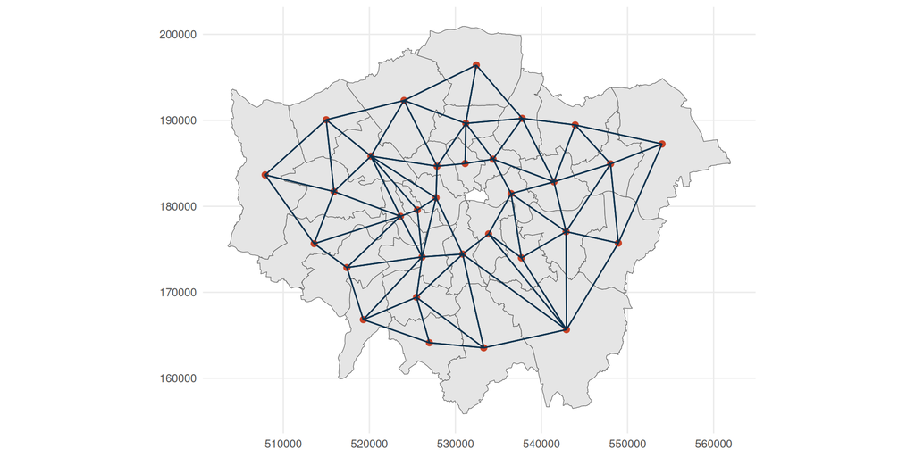

## Que faire dans le cas des counties – grille non régulière

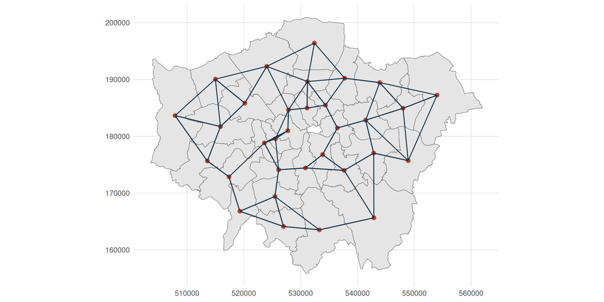

## Champs de Markov

**Definition**

- $(X_s, s\in D)$ est un champs de Markov si

$$\mathcal{L} \left ( X_{s} \vert X^s \right) = \mathcal{L} \left ( X_{s} \vert X_{\partial_s}\right)$$
* Pour définir un champs de Markov, on définit des lois conditionnelles mais encore faut-il que la loi jointe existe !

## Conditionnelles locales $\ne$ loi conjointe : un contre-exemple

Variables dans {0,1} et conditionnelles imposées :

$$P(X_1 = X_2 \mid X_3) = 1,\;
P(X_2 = X_3 \mid X_1) = 1,\;
P(X_3 = X_1 \mid X_2) = 1$$

i.e chaque site **doit être égal** à ses deux voisins.

### Pourquoi c’est impossible ?

Si une loi conjointe existait, elle serait supportée par :

$$(0,0,0) \text{ ou } (1,1,1)$$

mais les trois conditionnelles imposent des contraintes **sur-déterminées** :

- elles doivent être vraies **quelle que soit** la valeur du troisième site **aucune loi jointe ne peut satisfaire simultanément ces trois conditionnelles.**

## Notion de cliques

**Definition** On appelle Clique un ensemble de points tels que chaque paire de points du sous-ensemble est connectée est voisin.

### Exemple

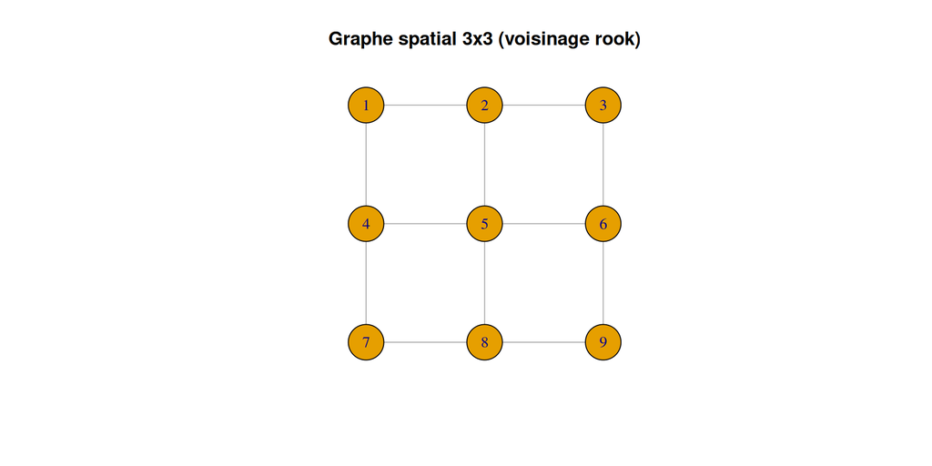

Quelles sont les cliques de ce graphe de voisinage

## Champs de Gibbs - une sous famille des champs de Markov

**Definition** Soit $\mathcal{E}$ un espace fini, $\boldsymbol{X}=\left (X_s, s\in D\right)$ à valeurs dans $\mathcal{E}^{|D|}$. $\boldsymbol{X}$ est un champs de Gibbs si
$${\mathbb{P}}\left (\boldsymbol{X}\right ) = Z^{-1} e^{- \sum_c \Phi_c(X_c) },$$
où la somme est prise sur toutes les cliques $c$, $\Phi_c$ est un potentiel i.e une fonction définie sur une partie de $D$ et à valeurs dans ${\mathbb{R}}$ et $X_c = \lvert X_s, s \in c \lVert$ et $Z$ est une constante de normalisation en général inconnue.

## Loi conditionnelle pour un champs de Gibbs

$${\mathbb{P}}(x_F \vert x^F) = {\mathbb{P}}(x_F \vert x_{\partial{F}}) = Z^{-1}_F e^{U_\phi(x_F\vert x_{\partial{F}})}$$
avec $U_\phi(x_F\vert x_{\partial{F}}) = \sum_{c, F\cup c \ne \emptyset} \Phi_c(X_c)$.

Pour définir un champs de Gibbs il faut donc

## Champs gaussiens et Champs de Gibbs

Soit $\boldsymbol{X}$ un champs gaussien sur $D$ de loi $\mathcal{N}(\mu, \Sigma)$,

- Quelle est la loi de $\boldsymbol{X}$ ? (on peut utiliser la précision, inverse de la covarainec pour plus de simplicité)
- En faisant le lien avec la forme d’un champs de Gibbs, identifier des cliques
- En déduire la décomposition de l’énergie sous forme de cliques
- Ecrire la loi de $X_i$ sachant tout le reste
- Que signifie que $Q_{ij}= 0$ ?

## Résumé sur les champs de Gibbs

Pour définir un champs de Gibbs

- on se donne les parties $A$ de $D$
- on se donne des potentiels $\Phi_A$
- Vérifier que $exp U_\phi$ est intégrable

## Theorem de Hammersley Clifford

Si $\pi$ est un champs de Markov pour un graphe $G$ symétrique et pour tout $x$, $\pi(x)>0$ alors $\pi$ est un champs de Gibbs dont les potentiels sont limités aux cliques de $G$.

Tout champs de Gibbs est un champs de markov pour le graphe engendré par les potentiels de Gibbs

## Cas particulier de la famille exponentielle

On se donne un graphe de voisinage $G$ et on définit les lois conditionnelles sous la forme de la famille exponentielle.

$$log\pi(x_i\vert \partial{x_i}) = A_i(\partial{x_i}) B_i(x_i) + C_i(x_i) + D_i(\partial{x_i})$$
où $A_i(\partial{x_i}) = \alpha_i + \sum_{j\in \partial_i} \beta_{ij} x_j$ et pour assurer la symétrie $\beta_{ij}=\beta_{ji}$

Alors $\pi$ est un champs de Gibbs avec

$$\Phi_i(x_i) = \alpha_i B_i(x_i) + C_i(x_i), \quad \Phi_{i,j}(x_i,x_j) = \beta_{ij}B_i(x_i)B_j(x_j)$$

# Des cas particuliers fréquents

## Modèle SAR - Cadre Gaussien

$$Z = BZ + \nu$$

- $B$ : Matrice de poids spatiaux
- $\nu$ : Bruit normal $\nu \sim N(0, \Omega)$
  - $\Omega$ est une matrice diagonale dont tous les termes diagonaux sont strictement positifs.
  - Par convention les termes $b_{ii}$ de la matrice sont nuls (les sites ne dépendent pas d’eux-mêmes)
- Modèle simultané : chaque variable dépend directement de ses voisines

Puisque $Z - BZ = \nu$,
$$\Sigma_{SAR} = (I - B)^{-1} \Omega (I - B^T)^{-1}$$

### Remarques

- La dépendance spatiale est due à B.
- $B$ n’est pas obligatoirement symétrique, en effet la forme quadratique $(I - B)^{-1} \Omega (I - B^T)^{-1}$ est symétrique même si $B$ ne l’est pas
- Il faut que $I-B$ soit inversible

## Modèle CAR

$$Z_i | Z_{-i} \sim N \left( \sum_{j \neq i} c_{ij} Z_j, \sigma^2 / m_{ii} \right)$$

$Z_{-i}$ désigne l’ensemble des $Z_j$ pour $j\ne i$.

- La matrice $C$ est la matrice des poids spatiaux et on impose $C_{ii}=0$ (on ne définit pas $Z_i$ conditionnellement à lui même)
- La matrice $M$ est diagonal et ses termes diagonaux sont positifs.
- Dépendance conditionnelle : chaque variable est conditionnée aux voisines
- Matrice de covariance :

$$\Sigma_{CAR} = (I - C)^{-1} M$$

### Remarques

La loi conditionnelle de $Z_i$ est une combinaison linéaire des autres variables.

Les valeurs de $m_{ii}$ se sont pas toutes identiques

Ce n’est pas évident que ca définit une loi jointe qui existe

## Modèle CAR

- Existence du modèle CAR sous réserve que $(I-C)^{-1} M$ est définie positive (Besag (1974)) et alors

$$Z \sim \mathcal{N}(0, \Sigma_{CAR}), \quad \Sigma_{CAR} = (I-C)^{-1} M$$
Puisque $\Sigma_{CAR}$ doit être symétrique alors
$$\frac{C_{ij}}{m_{ii}} =\frac{C_{ji}}{m_{jj}}$$

## Les matrices de poids

En pratique, on choisit la matrice $B$ du modèle SAR sous la forme $B = \rho_s W$ et

la matrice $C$ du CAR sous la forme $C=\rho_C W$.

La matrice $W$ est une matrice de poids tels que

- $W_{ij}\ne 0$ si $i$ et $j$ sont voisins

## Impact du voisinage

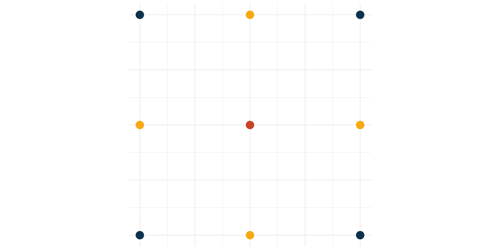

On souhaite définir un CAR sous la forme

$$Z_i \vert Z_{-i} \sim \mathcal{N}(\sum_{j, j\in V(i)} Z_j, \sigma^2/m_{ii})$$

Est-ce un modèle CAR valide ?

## Relations entre CAR et SAR

**Théorème** Ver Hoef et al. (2018) :

- Tout modèle SAR peut s’écrire de manière unique comme un modèle CAR
- Tout modèle CAR peut s’écrire de manière comme un modèle SAR mais cette écriture n’est pas unique

## Estmation des modèles CAR et SAR

En général CAR et SAR ne sont utilisés que pour le bruit

on a donc des modèles

$Y = X\beta + Z + \epsilon$ où $Z$ a une structure SAR ou CAR et $\epsilon$ un bruit pur.

Pour l’estimation, on utilise un algorithme itératif

- On estime $\tilde{\beta}$ par les MCO
- On calcule les résidus $\tilde{Z} = Y- X \tilde{\beta}$ et on estime $\hat{\Sigma}$ la structure de covariance,
- on injecte cette structure dans la vraisemblance et on estime $\tilde{\beta}$ par les moindres carrés généralisés
- on recommence jusqu’à stabilisation.

## Tester si il y dépendance - Indice de Moran $I$

**Définition**
$$I = \frac{n}{\sum_{i\neq j} w_{ij}} \frac{\sum_{i\neq j} w_{ij}(x_i-\bar x)(x_j-\bar x)} {\sum_i (x_i-\bar x)^2}$$

- $w_{ij}$ : poids spatiaux (voisinage, distance, contiguïté)
- $\bar x$ : moyenne globale

### Interprétation

- $I > 0$ : valeurs similaires regroupées (**clustering**)
- $I < 0$ : voisinage contrasté (**dispersion**)
- $I = 0$ : absence de structure spatiale

### Test de Moran

$$H_0 : \text{pas d'autocorrélation spatiale}$$
$$\frac{I- {\mathbb{E}}(I)}{\sqrt{Var(I)}} \approx \mathcal{N}(0, 1)$$
avec ${\mathbb{E}}(I) = (n-1)^{-1}$ et
$$Var(I) = \frac{s_1}{s_0^2}, \quad s_0 =\sum_{i,j} w_{ij}, \quad s_1 = \sum_{i,j} w_{ij}^2 +w_{ij}w_{ji}$$

## Tester si il y dépendance - Indice de Geary $C$

Mesurer l’**autocorrélation spatiale locale**, plus sensible aux **abruptes variations**.

### Définition

$$C = \frac{(n-1)}{2\sum_{i\neq j} w_{ij}}
\frac{\sum_{i\neq j} w_{ij}(x_i - x_j)^2}
{\sum_i (x_i-\bar x)^2}$$

### Interprétation

- $C < 1$ : autocorrélation **positive**
- $C > 1$ : autocorrélation **négative**
- $C = 1$ : absence de structure spatiale

**Plus C est grand, moins les valeurs voisines se ressemblent**

### Test de Geary

$$H_0 : \text{pas d'autocorrélation spatiale}$$

approche de la loi sous $H_0$ par permutation

## Que se passe-t-il si on n’est plus dans un cadre gaussien ?

On compte le nombre de personnes atteintes de cancer soigné dans les hopitaux.

Chaque hopital est associé à un sercteur géographique, pour lequel on a des descripteurs environnementaux.

Quel modèle proposez vous ?

## Références

Besag, Julian. 1974. “Spatial Interaction and the Statistical Analysis of Lattice Systems.” *Journal of the Royal Statistical Society: Series B (Methodological)* 36 (2): 192–225.

Cressie, Noel. 2015. *Statistics for Spatial Data*. John Wiley & Sons.

Ver Hoef, Jay M., Ephraim M. Hanks, and Mevin B. Hooten. 2018. “On the Relationship Between Conditional (CAR) and Simultaneous (SAR) Autoregressive Models.” *Spatial Statistics* 25: 68–85. https://doi.org/https://doi.org/10.1016/j.spasta.2018.04.006.